# Lecture 6: Model Checking in the Cox Model I

STA310 Survival Analysis · Collett Chapter 4 (part 1)

2026-10-06

## Today

1. Why check the model?
2. Residuals for survival data: overview
3. Cox–Snell, martingale, deviance residuals
4. The proportional hazards assumption
5. Graphical checks and `cox.zph`
6. What to do when PH fails

**Learning goals**

You can

- name what can go wrong in a Cox model
- choose the residual that fits a given question
- check proportional hazards graphically and formally in R
- interpret `cox.zph` output and react sensibly to a violation

## Recap

- Cox model: $h(t \mid x) = h_0(t)\exp(\beta_1 x_1 + \dots + \beta_p x_p)$
- $\exp(\beta_j)$ = hazard ratio (HR), **the same at all times**
- Lectures 4-5: fitting, interpreting, selecting variables

**Today’s question**: we have a fitted model. Can we trust the HRs we report?

# Why check the model?

## What can go wrong

| Problem | Question | Consequence |
| --- | --- | --- |
| Non-proportional hazards | Is the HR constant over time? | One HR is an average; may mislead |
| Wrong functional form | Is the effect of a continuous $x$ linear on the log hazard? | Biased or misleading HR per unit |
| Outliers | Are some patients badly predicted? | Poor fit, possibly a data error |
| Influential patients | Does one patient drive the estimate? | Unstable conclusions |
| Missing covariates / interactions | Is the model too simple? | Confounding, wrong effects |

Today: **residuals** and the **PH assumption**. Next lecture: influence and functional form in more depth.

## Link to interpreting an HR

“Combination therapy has HR 0.5” claims that at **every** time, the hazard is halved.

- If the true HR is 0.2 early and 1.0 late, the reported 0.5 describes neither period
- If $\log$ hazard is not linear in age, “HR per year of age” is not one number
- The estimate is still a number: only checks reveal that its interpretation fails

**Note**

No model is exactly true. We look for **departures large enough to change conclusions**, not for perfection.

## Running example 1: multiple myeloma

48 patients, survival time in months; `bun` (blood urea nitrogen), `hb` (haemoglobin), `ca`, `pcells`, `protein`, `age`, `sex`.

```r
fit_my <- coxph(
  Surv(time, status) ~ age + sex + bun + ca + hb + pcells + protein,
  data = myeloma
)
broom::tidy(fit_my, exponentiate = TRUE, conf.int = TRUE) |>
  select(term, HR = estimate, conf.low, conf.high, p.value) |>
  mutate(across(where(is.numeric), \(x) round(x, 3)))
```

```
# A tibble: 7 × 5
  term       HR conf.low conf.high p.value
  <chr>   <dbl>    <dbl>     <dbl>   <dbl>
1 age     0.982    0.93       1.04   0.517
2 sex     0.779    0.354      1.72   0.536
3 bun     1.02     1.01       1.03   0
4 ca      1.01     0.781      1.31   0.92
5 hb      0.875    0.765      1.00   0.052
6 pcells  0.999    0.986      1.01   0.837
7 protein 0.505    0.218      1.17   0.112
```

We use this model to illustrate the residuals.

# Residuals

## Residuals in survival analysis

In linear regression: $e_i = y_i - \hat y_i$. For survival data this is not possible:

- $T_i$ is **censored** for some patients, so there is no observed $y_i$ to subtract from
- the distribution is skewed, with a hazard rather than a mean

Instead, several residuals are defined, **each designed for one purpose**:

- **Cox–Snell**: overall fit
- **Martingale**: functional form
- **Deviance**: outliers
- **Schoenfeld**: proportional hazards

## Cox–Snell residuals

For patient $i$ with covariates $x_i$ and observed time $t_i$:

$$r_{Ci} = \hat H_i(t_i) = \hat H_0(t_i)\exp(\hat\beta' x_i)$$

If the model is correct, $\{r_{Ci}\}$ behave like a (censored) sample from a unit exponential distribution, $H(T) \sim \text{Exp}(1)$.

**Check**: compute the Nelson–Aalen estimate $\hat H_{CS}(r)$ of the cumulative hazard of the $r_{Ci}$ (treating the censoring indicator as is) and plot it against $r$. For a unit exponential, $H(r) = r$: the points should follow the **45-degree line**.

## Cox–Snell in R

R gives martingale residuals $r_{Mi} = \delta_i - r_{Ci}$, so $r_{Ci} = \delta_i - r_{Mi}$.

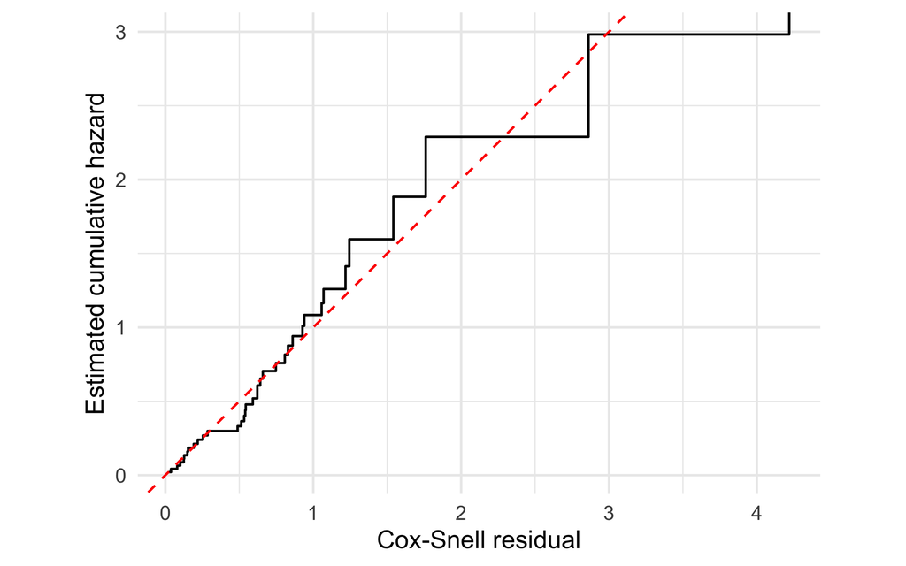

```r
cs <- myeloma$status - residuals(fit_my, type = "martingale")
na <- survfit(Surv(cs, myeloma$status) ~ 1)
tibble(r = na$time, H = -log(na$surv)) |>
  ggplot(aes(r, H)) +
  geom_step() +
  geom_abline(slope = 1, intercept = 0, linetype = 2, colour = "red") +
  coord_equal() +
  labs(x = "Cox-Snell residual", y = "Estimated cumulative hazard")
```

Interpretation: the curve follows the line reasonably, with only 48 patients, so we expect some wiggling. No gross lack of fit is visible.

## Limitations of the Cox–Snell plot

**Warning**

- Residuals use the **estimated** $\hat\beta$ and $\hat H_0$, so they are not exactly exponential; the **right tail** is especially unreliable
- Censored observations make the tail even more variable
- The plot is an **overall** check: it is insensitive to specific problems such as one covariate with non-PH or a wrong functional form
- It is poorly able to say **what** is wrong

Collett’s recommendation: Cox–Snell is a rough first look. Use targeted residuals for specific questions.

## Martingale residuals

$$r_{Mi} = \delta_i - \hat H_0(t_i)\exp(\hat\beta'x_i) = \delta_i - r_{Ci}$$

- Observed events minus expected events for patient $i$
- Range $(-\infty, 1]$; mean zero; **skewed**: censored patients get $r_M \le 0$, events $r_M \in (0, 1]$
- Sum to zero, approximately uncorrelated

Main use: **functional form** of a continuous covariate.

## Martingale residuals: functional form

Idea: fit a model **without** covariate $x$ (for a single covariate: the null model), then plot $r_{M}$ against $x$ and add a smoother.

- The smooth shows the shape of the true relation between $x$ and the log hazard
- Straight line: linear term is fine
- Curve (U-shape, plateau, threshold): transform or use a more flexible term

```r
fit0 <- coxph(Surv(time, status) ~ 1, data = d) # null model
# or the model with all the OTHER covariates
rm <- residuals(fit0, type = "martingale")
plot(d$x, rm)
lines(lowess(d$x, rm))
```

## Example: `bun` and `hb` in myeloma

Residuals from the model **without** the covariate being examined, i.e. adjusted for the others.

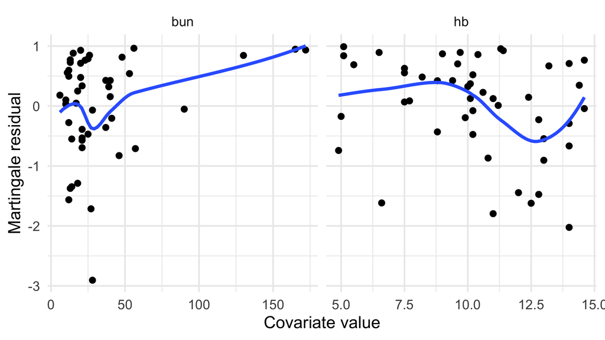

```r
rm_bun <- residuals(
  coxph(
    Surv(time, status) ~ age + sex + ca + hb + pcells + protein,
    data = myeloma
  ),
  type = "martingale"
)
rm_hb <- residuals(
  coxph(
    Surv(time, status) ~ age + sex + bun + ca + pcells + protein,
    data = myeloma
  ),
  type = "martingale"
)
bind_rows(
  tibble(x = myeloma$bun, r = rm_bun, var = "bun"),
  tibble(x = myeloma$hb, r = rm_hb, var = "hb")
) |>
  ggplot(aes(x, r)) +
  geom_point() +
  geom_smooth(method = "loess", se = FALSE, formula = y ~ x) +
  facet_wrap(~var, scales = "free_x") +
  labs(x = "Covariate value", y = "Martingale residual")
```

## Reading the plot

- `bun`: the smooth is flat over the bulk (median 21) and rises only in the sparse upper tail — 7 patients have `bun` > 50 (5 died). That rise rests on a handful of points, so the plot is too noisy to settle `bun`’s functional form. Skew is a reason to *check* `log(bun)`, but a linear term is actually preferred here (lower AIC).
- `hb`: the smooth is not a straight line — it rises at low `hb`, falls through the middle, then turns back up near `hb` = 14. Low `hb` is clearly high risk (4 of 5 with `hb` < 6 died); the ends are small clusters, not empty. With 48 patients the functional form is hard to pin down.

**Important**

Skewed martingale residuals + few points: the smoother is noisy. Interpret **shape**, not wiggles. Lecture 7 treats this in depth (transformations, splines).

## Deviance residuals

Martingale residuals are skewed. The deviance residual is a transformation to make them more symmetric:

$$r_{Di} = \operatorname{sign}(r_{Mi})\sqrt{-2\left[r_{Mi} + \delta_i\log(\delta_i - r_{Mi})\right]}$$

- Roughly symmetric around 0, approximately standard normal if little censoring
- Large $|r_D|$ (say $> 2$ to $2.5$): patient poorly fitted by the model, **outlier**
- Plot against the linear predictor $\hat\eta_i = \hat\beta'x_i$, against covariates, or against index

Positive: died **earlier** than the model predicts. Negative: lived longer (or censored while the model expected an event).

## Deviance residuals in R

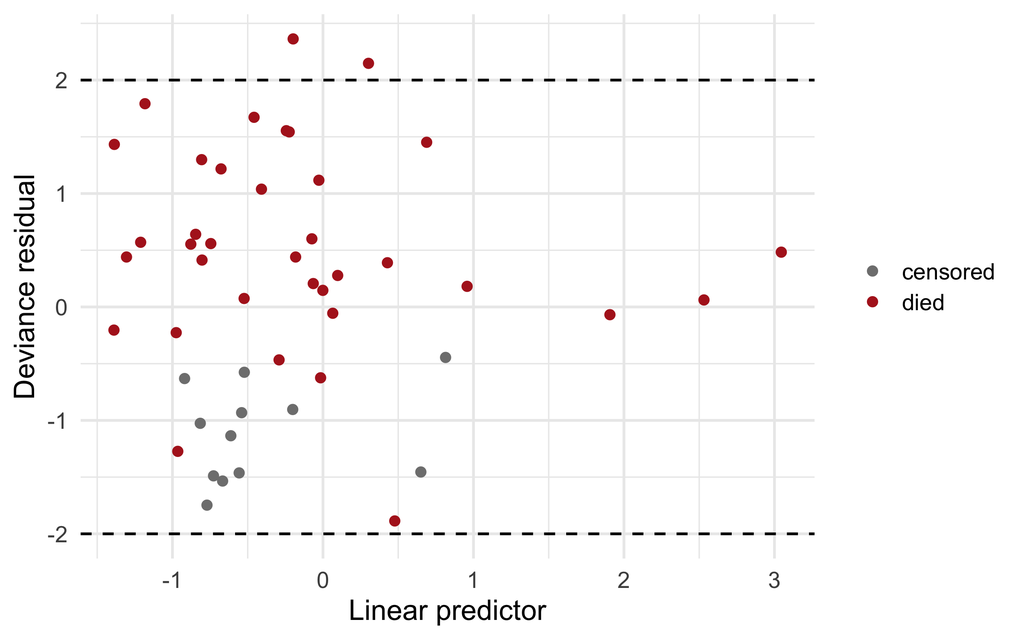

```r
myeloma |>
  mutate(
    dev = residuals(fit_my, type = "deviance"),
    lp = predict(fit_my, type = "lp")
  ) |>
  ggplot(aes(lp, dev, colour = factor(status))) +
  geom_point(size = 2) +
  geom_hline(yintercept = c(-2, 2), linetype = 2) +
  scale_colour_manual(
    values = c("grey50", "firebrick"),
    labels = c("censored", "died")
  ) +
  labs(x = "Linear predictor", y = "Deviance residual", colour = NULL)
```

```r
max(abs(residuals(fit_my, type = "deviance")))
```

```
[1] 2.362962
```

Largest $|r_D|$ is 2.36. An outlier is **not** automatically an influential point: that comes next lecture.

## Schoenfeld residuals

Defined **only at event times**, one per covariate per event.

For event at $t_i$ with covariates $x_i$:
$$r_{Si} = x_i - \hat{\bar x}(t_i)$$
the covariate of the patient who failed **minus** the weighted average covariate in the risk set at $t_i$.

Use: the PH assumption (the main part of this lecture).

## Summary table: residuals

| Residual | R: `residuals(fit, type = )` | Purpose | A problem looks like |
| --- | --- | --- | --- |
| Cox–Snell | `"martingale"`, then $\delta - r_M$ | Overall fit | Cumulative hazard plot departs from 45-degree line |
| Martingale | `"martingale"` | Functional form of a continuous $x$ | Smooth against $x$ (from model without $x$) is not a straight line |
| Deviance | `"deviance"` | Outliers | $\|r_D\| > 2$-$2.5$; isolated points |
| Schoenfeld (scaled) | `"scaledsch"` or `cox.zph` | Proportional hazards | Smooth against time has a slope |
| Score / dfbeta | `"dfbeta"`, `"score"` | Influence | Next lecture |

# Proportional hazards

## The assumption

$$\frac{h(t \mid x_1)}{h(t \mid x_0)} = \exp\{\beta(x_1 - x_0)\} \quad \text{for all } t$$

Equivalent statement: $\log H(t \mid x) = \log H_0(t) + \beta'x$, so on the **log cumulative hazard scale the curves for different $x$ are parallel**.

Violations seen in practice:

- hazards **converge** (effect of a treatment wears off, or early selection)
- hazards **diverge** (effect builds up)
- hazards **cross** (surgery: early risk, later benefit)

## Three tools

1. **Graphical** (grouped covariate): log-minus-log plot
2. **Graphical** (any covariate): scaled Schoenfeld residuals versus time with a smoother
3. **Formal test**: `cox.zph`, a test of zero slope of the Schoenfeld residuals against (a transformation of) time

We first look at a data set where PH is clearly violated, then at examples where it is fine.

## Running example 2: veteran lung cancer trial

Randomised trial of two chemotherapies in 137 men with inoperable lung cancer (`survival::veteran`).

- `trt`: standard / test; `celltype`: squamous, smallcell, adeno, large
- `karno`: Karnofsky performance score (10-100, 100 = normal)
- `time` in days; 128 deaths

```r
fit_vet <- coxph(Surv(time, status) ~ trt + celltype + karno + age, data = vet)
broom::tidy(fit_vet, exponentiate = TRUE, conf.int = TRUE) |>
  select(term, HR = estimate, conf.low, conf.high, p.value) |>
  mutate(across(where(is.numeric), \(x) round(x, 3)))
```

```
# A tibble: 6 × 5
  term                 HR conf.low conf.high p.value
  <chr>             <dbl>    <dbl>     <dbl>   <dbl>
1 trttest           1.35     0.905     2.03    0.141
2 celltypesmallcell 2.36     1.38      4.01    0.002
3 celltypeadeno     3.25     1.82      5.81    0
4 celltypelarge     1.50     0.859     2.60    0.154
5 karno             0.968    0.958     0.978   0
6 age               0.991    0.973     1.01    0.334
```

## Log-minus-log plot

For a categorical covariate: estimate $\hat S(t)$ per group by Kaplan–Meier and plot $\log\{-\log \hat S(t)\} = \log \hat H(t)$ against $t$ (or $\log t$).

**PH holds** $\Rightarrow$ curves are **parallel** (vertical distance $=\beta$).

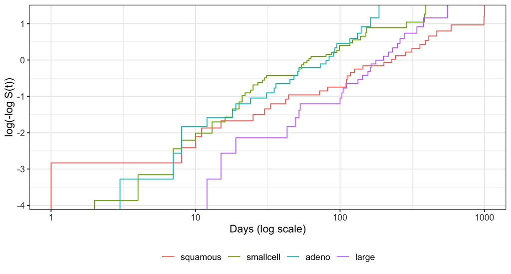

```r
survfit2(Surv(time, status) ~ celltype, data = vet) |>
  ggsurvfit(type = "cloglog") +
  scale_x_log10() +
  labs(x = "Days (log scale)", y = "log(-log S(t))")
```

## Reading the log-minus-log plot

- Parallel curves: PH plausible. Crossing or converging curves: PH doubtful.
- Check in the plot whether the curves keep a constant vertical distance; in the first part of follow-up, based on few events, they are noisy. Here the log-minus-log plot is only suggestive, and the formal test below gives a firmer answer.
- Weakness: **subjective**; for a continuous $x$ you must group it, and with small groups the curves are noisy

**Tip**

Use the same cut-points that you would use in a clinical presentation, and look for **systematic** divergence, not small wiggles.

## Continuous covariate: group it

Karnofsky score, dichotomised at 60 for the plot only:

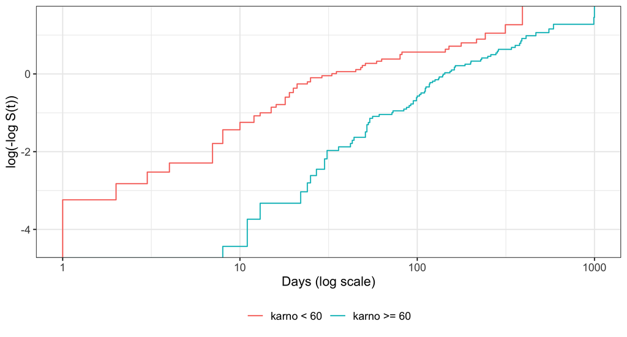

```r
vet <- vet |>
  mutate(
    karno_grp = factor(karno >= 60, labels = c("karno < 60", "karno >= 60"))
  )
survfit2(Surv(time, status) ~ karno_grp, data = vet) |>
  ggsurvfit(type = "cloglog") +
  scale_x_log10() +
  labs(x = "Days (log scale)", y = "log(-log S(t))")
```

Compare the vertical distance between the curves early and late: parallel curves would keep it constant. Together with the Schoenfeld plot below, this suggests that the effect of `karno` changes over time.

## Scaled Schoenfeld residuals: `cox.zph`

```r
zph <- cox.zph(fit_vet)
zph
```

```
          chisq df       p
trt       0.284  1 0.59382
celltype 14.884  3 0.00192
karno    12.977  1 0.00032
age       1.874  1 0.17099
GLOBAL   29.179  6 5.6e-05
```

- Each row tests: slope of the scaled Schoenfeld residuals against time is zero. $H_0$: PH holds for that covariate.
- **GLOBAL**: simultaneous test of all covariates (df = number of coefficients)
- Default time transformation: Kaplan–Meier (`transform = "km"`); `"identity"`, `"log"`, `"rank"` are alternatives

## Interpreting the output

**Note**

A non-significant `trt` test does not “prove” PH for `trt`. Also, a violation in one covariate can distort the tests for others.

## Schoenfeld plot by hand with ggplot2

`zph$y` holds scaled residuals (columns = coefficients), `zph$time` the event times. Adding $\hat\beta$ gives a pointwise estimate of $\beta(t)$.

```r
zph_df <- function(z, fit, var) {
  tibble(time = z$time, beta_t = z$y[, var] + coef(fit)[var])
}
plot_zph <- function(z, fit, var) {
  ggplot(zph_df(z, fit, var), aes(time, beta_t)) +
    geom_point(alpha = 0.6) +
    geom_smooth(
      method = "loess",
      span = 0.8,
      formula = y ~ x,
      colour = "firebrick"
    ) +
    geom_hline(yintercept = coef(fit)[var], linetype = 2) +
    scale_x_log10() +
    labs(x = "Time (log scale)", y = paste0("Beta(t) for ", var))
}
```

The dashed line is the constant coefficient under PH.

## `karno`: PH fails

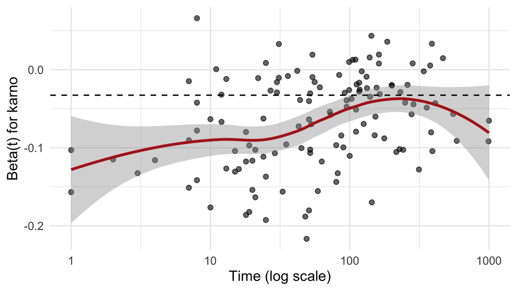

```r
plot_zph(zph, fit_vet, "karno")
```

The smoothed $\hat\beta(t)$ for `karno` starts clearly negative (a high score protects) and rises towards 0 for later times: the protective effect of a good performance status **fades**. A single HR of 0.968 per point averages over this.

## Compare with a covariate where PH holds

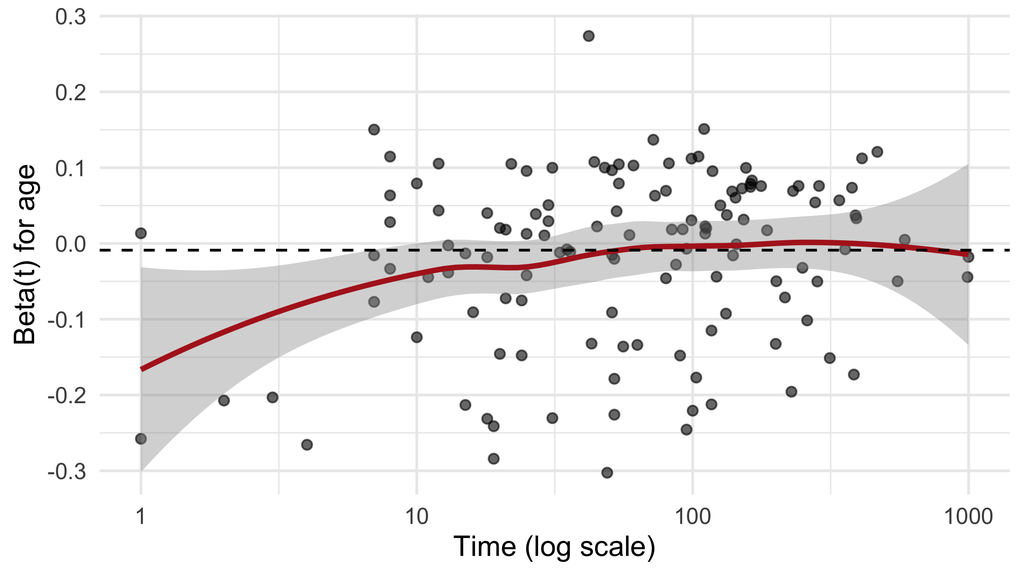

```r
plot_zph(zph, fit_vet, "age")
```

The smooth stays near the dashed line: no trend.

## Built-in plot

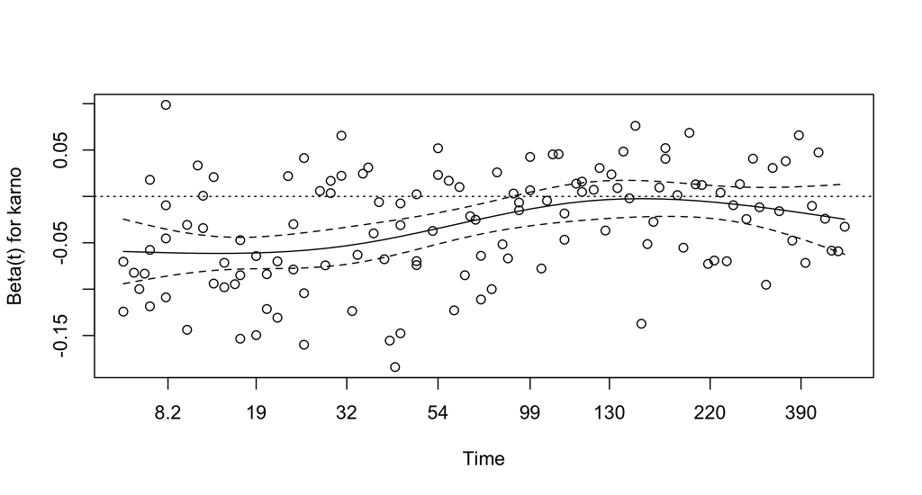

```r
plot(zph[3], resid = TRUE) # third coefficient group in the order of the table
abline(h = 0, lty = 3)
```

`plot.cox.zph` (what `survminer::ggcoxzph` wraps) shows the smooth with a confidence band; the ggplot version above gives full control.

## Example where PH is fine: myeloma

```r
cox.zph(fit_my)
```

```
         chisq df    p
age     0.1280  1 0.72
sex     0.7724  1 0.38
bun     0.8564  1 0.35
ca      0.3629  1 0.55
hb      0.0428  1 0.84
pcells  2.1903  1 0.14
protein 0.4325  1 0.51
GLOBAL  4.0974  7 0.77
```

All $p > 0.1$ and GLOBAL $p =$ 0.77. No evidence against PH. But $n = 48$ with 36 deaths: low **power**.

## Ovarian cancer and breast cancer

Ovarian cancer (n = 26), treatment, age, residual disease, performance:

```r
fit_ov <- coxph(Surv(time, status) ~ treat + age + rdisease + perf, data = ovar)
cox.zph(fit_ov)
```

```
         chisq df     p
treat    0.584  1 0.445
age      0.212  1 0.645
rdisease 1.186  1 0.276
perf     2.997  1 0.083
GLOBAL   4.494  4 0.343
```

Breast cancer (n = 45), HPA staining:

```r
fit_br <- coxph(Surv(time, status) ~ stain, data = breast)
cox.zph(fit_br)
```

```
       chisq df    p
stain   1.32  1 0.25
GLOBAL  1.32  1 0.25
```

No test is significant at 5%. With 26 and 45 patients (few events) we could miss moderate departures.

## Breast cancer: log-minus-log plot

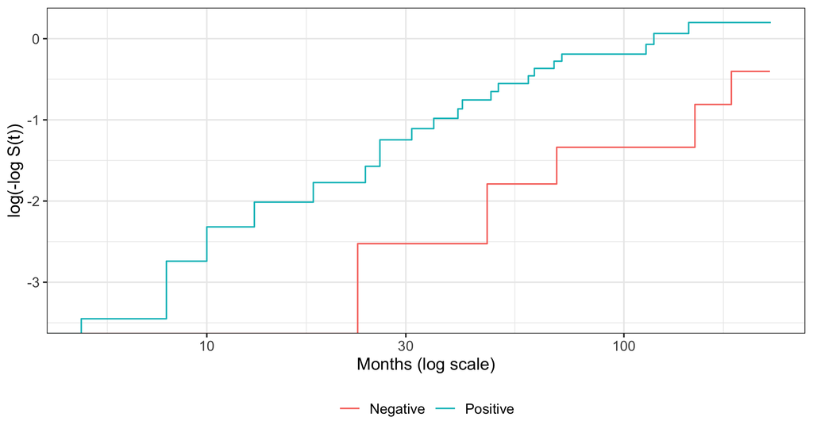

```r
survfit2(Surv(time, status) ~ stain, data = breast) |>
  ggsurvfit(type = "cloglog") +
  scale_x_log10() +
  labs(x = "Months (log scale)", y = "log(-log S(t))")
```

Curves are roughly parallel apart from early noise. PH is reasonable for `stain` but the data cannot exclude moderate deviations.

## Power and judgement

- The test is a **test of a slope**: small $n$ $\to$ low power; large $n$ $\to$ trivial deviations become “significant”
- Result depends on the time transformation chosen
- Many covariates $\to$ multiple testing; the GLOBAL line helps somewhat

**Important**

**Combine the test with the plot.** Significant test + small visible trend in a large study: perhaps ignorable. Non-significant test + clear trend in a small study: do not rely on the p-value. Ask: would a time-varying HR change the clinical message?

## Making the test intuitive: a quick check by splitting

```r
vet2 <- survSplit(
  Surv(time, status) ~ .,
  data = vet,
  cut = 90,
  episode = "period"
)
fit_split <- coxph(
  Surv(tstart, time, status) ~ karno:strata(period) + celltype + trt + age,
  data = vet2
)
broom::tidy(fit_split, exponentiate = TRUE) |>
  filter(str_detect(term, "karno")) |>
  select(term, HR = estimate, p.value) |>
  mutate(across(where(is.numeric), \(x) round(x, 3)))
```

```
# A tibble: 2 × 3
  term                            HR p.value
  <chr>                        <dbl>   <dbl>
1 karno:strata(period)period=1 0.953   0
2 karno:strata(period)period=2 1.00    0.655
```

Separate `karno` HRs before and after day 90: the estimated log-HR per point is -0.048 before and 0.005 after day 90, i.e. the effect has essentially vanished, in line with the plot (day 90 is an arbitrary cut-point, used for illustration).

# When PH fails

## Options

1. **Stratify** on the offending (categorical) covariate: separate $h_{0g}(t)$ per group, common $\beta$ for the rest
2. **Time-varying coefficient** $\beta(t)$, e.g. interaction with $\log t$ (lectures 10-11)
3. **Another effect measure**: e.g. restricted mean survival time difference, or HRs reported for **separate time periods**
4. **Rethink the model**: PH can fail because of a missing covariate or the wrong functional form

Which one depends on the aim: is the violating variable a **confounder** (stratify) or the **exposure of interest** (model its effect)?

## Option 1: stratify

```r
fit_str <- coxph(
  Surv(time, status) ~ trt + karno + age + strata(celltype),
  data = vet
)
broom::tidy(fit_str, exponentiate = TRUE, conf.int = TRUE) |>
  select(term, HR = estimate, conf.low, conf.high, p.value) |>
  mutate(across(where(is.numeric), \(x) round(x, 3)))
```

```
# A tibble: 3 × 5
  term       HR conf.low conf.high p.value
  <chr>   <dbl>    <dbl>     <dbl>   <dbl>
1 trttest 1.34     0.891     2.01    0.16
2 karno   0.963    0.952     0.974   0
3 age     0.988    0.97      1.01    0.225
```

```r
cox.zph(fit_str)
```

```
          chisq df      p
trt     0.00466  1 0.9456
karno   6.72046  1 0.0095
age     2.52332  1 0.1122
GLOBAL 12.18403  3 0.0068
```

Recall Lecture 5 (where pros and cons are discussed): each cell type gets its own baseline hazard and no HR for `celltype` is estimated. Stratifying cannot help with a continuous covariate such as `karno`, and `cox.zph` still shows the `karno` problem.

## Option 2: coefficient depending on time (preview)

Let $\beta(t) = \beta_0 + \beta_1 g(t)$ with $g(t) = \log t$:

```r
fit_tt <- coxph(
  Surv(time, status) ~ trt + celltype + karno + age + tt(karno),
  data = vet,
  tt = function(x, t, ...) x * log(t)
)
summary(fit_tt)$coefficients |> round(4)
```

```
                     coef exp(coef) se(coef)       z Pr(>|z|)
trttest            0.1647    1.1790   0.2092  0.7875   0.4310
celltypesmallcell  0.9197    2.5086   0.2760  3.3319   0.0009
celltypeadeno      1.1676    3.2144   0.2987  3.9094   0.0001
celltypelarge      0.3619    1.4361   0.2833  1.2777   0.2014
karno             -0.0832    0.9202   0.0173 -4.8067   0.0000
age               -0.0093    0.9907   0.0092 -1.0110   0.3120
tt(karno)          0.0137    1.0138   0.0044  3.1382   0.0017
```

The `tt(karno)` coefficient is the change of the `karno` log-HR per unit of $\log t$. Its test is essentially the same as `cox.zph`’s. Estimation details, interpretation and pitfalls: lectures 10-11.

## Option 3: other effect measures

- If the HR is not constant, one number does not describe the effect
- Alternatives: difference in **restricted mean survival time** to horizon $\tau$, or difference in survival probability at a clinically relevant time, with KM curves shown
- Honest reporting: **show the curves** and state that the HR is an average

## Example: wanes with time?

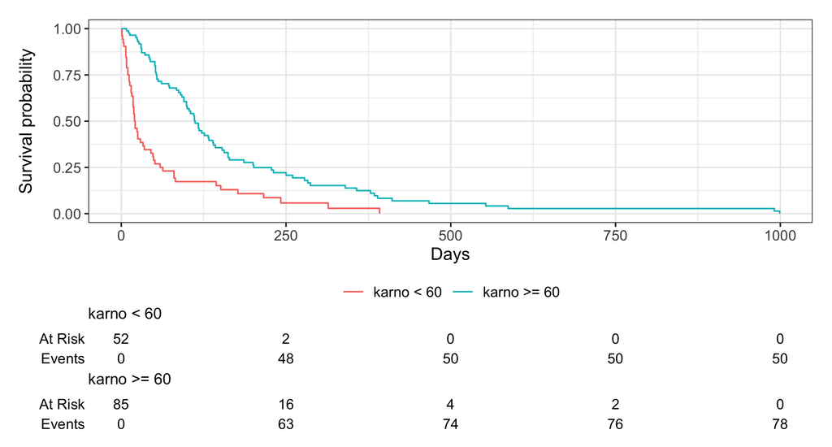

```r
survfit2(Surv(time, status) ~ karno_grp, data = vet) |>
  ggsurvfit() +
  add_risktable() +
  labs(x = "Days", y = "Survival probability")
```

## A workflow

```
flowchart LR
  A[Fit Cox model] --> B[cox.zph: global and per covariate]
  B --> C[Plot scaled Schoenfeld residuals]
  C --> D{Relevant violation?}
  D -- no --> E[Report HRs, mention check]
  D -- yes --> F[Stratify / time-varying effect / other measure]
  F --> B
```

[output not shown]

Remember to also check functional form and influence (next lecture).

## In-class exercise

Use the **ovarian cancer** data.

1. Fit `coxph(Surv(time, status) ~ treat + age + rdisease + perf)`.
2. Run `cox.zph()`. Which covariate has the smallest p-value? What does the GLOBAL line say?
3. Plot the scaled Schoenfeld residuals of `perf` against time and decide whether you see a trend.
4. Plot the martingale residuals of the null model against `age` with a lowess smooth.
5. With $n = 26$: how much weight would you put on a non-significant `cox.zph`?

**Tip**

Hint: `plot_zph(cox.zph(fit_ov), fit_ov, "perfPoor")` needs the coefficient name, check `names(coef(fit_ov))`.

## Take-home messages

- An HR is only meaningful if the model assumptions hold: check **PH**, **functional form**, **outliers/influence**
- Each residual has a purpose: Cox–Snell (overall), martingale (functional form), deviance (outliers), Schoenfeld (PH)
- PH: log-minus-log plot, Schoenfeld residuals against time, `cox.zph` (look at GLOBAL too)
- The test has low power in small samples and detects trivial effects in big ones: **always combine with plots**
- If PH fails: stratify, model $\beta(t)$, or report other measures. Think about the clinical meaning

**Next lecture**: Model checking II: influence (dfbeta, leverage), functional form in depth (transformations, splines) and a complete worked analysis.

**Reading**: Collett, Chapter 4 (4.1 residuals, 4.2 model fit, 4.4 proportional hazards; 4.3 influence for next time).